# Analyse dimensionnelle en présence d’une matrice creuse

```r
pacman::p_load(TAM, psych, tidyverse, data.table)
```

Nous présentons ici la situation où la matrice person-item est creuse, rendant impossible le calcul de l’ensemble des coefficients de corrélation polychoriques.

Nous prendrons comme exemple la table *data.fims.Aus.Jpn.scored* présente dans le package *TAM*. La matrice est pleine, mais elle sera traitée comme étant creuse.

```r
data("data.fims.Aus.Jpn.scored", package = "TAM")
DATA = data.fims.Aus.Jpn.scored %>% select(starts_with("M1"))
DATA %>% psych::describe()
```

|  | vars | n | mean | sd | median | trimmed | mad | min | max | range | skew | kurtosis | se |
| --- | --- | --- | --- | --- | --- | --- | --- | --- | --- | --- | --- | --- | --- |
| M1PTI1 | 1 | 6371 | 0.77 | 0.42 | 1 | 0.84 | 0 | 0 | 1 | 1 | -1.30 | -0.30 | 0.01 |
| M1PTI2 | 2 | 6371 | 0.76 | 0.43 | 1 | 0.83 | 0 | 0 | 1 | 1 | -1.23 | -0.49 | 0.01 |
| M1PTI3 | 3 | 6371 | 0.85 | 0.36 | 1 | 0.93 | 0 | 0 | 1 | 1 | -1.92 | 1.69 | 0.00 |
| M1PTI6 | 4 | 6371 | 0.57 | 0.49 | 1 | 0.59 | 0 | 0 | 1 | 1 | -0.29 | -1.92 | 0.01 |
| M1PTI7 | 5 | 6371 | 0.16 | 0.37 | 0 | 0.08 | 0 | 0 | 1 | 1 | 1.82 | 1.33 | 0.00 |
| M1PTI11 | 6 | 6371 | 0.80 | 0.40 | 1 | 0.87 | 0 | 0 | 1 | 1 | -1.47 | 0.16 | 0.01 |
| M1PTI12 | 7 | 6371 | 0.34 | 0.47 | 0 | 0.30 | 0 | 0 | 1 | 1 | 0.67 | -1.56 | 0.01 |
| M1PTI14 | 8 | 6371 | 0.40 | 0.49 | 0 | 0.37 | 0 | 0 | 1 | 1 | 0.41 | -1.83 | 0.01 |
| M1PTI17 | 9 | 6371 | 0.26 | 0.44 | 0 | 0.20 | 0 | 0 | 1 | 1 | 1.10 | -0.79 | 0.01 |
| M1PTI18 | 10 | 6371 | 0.61 | 0.49 | 1 | 0.64 | 0 | 0 | 1 | 1 | -0.46 | -1.79 | 0.01 |

[output cut: 4 more lines]

Le package *TAM* offre un outil de calcul de modèle factoriel, en utilisant la [forme en échelon](https://en.wikipedia.org/wiki/Row_echelon_form) des matrices.

Cette fonction est très gourmande en calcul, puisqu’elle réalise une analyse dimensionnelle à chaque itération!

De plus, cela implique d’avoir une idée du nombre de dimensions à rechercher **en amont**

# Analyses factorielle exploratoire

On commence par calculer un modèle exploratoire, en faisant l’hypothèse de facteurs non corrélés (rotation orthogonale).

```r
Start = Sys.time()
Modele = tam.fa(resp = DATA,
                irtmodel = "efa",
                nfactors = 2,
                control = list(progress = F,
                               increment.factor=1.2))
```

```
Three factors are required for identification -- general factor loadings set to be equal.
Proceed with caution.
Think about redoing the analysis with alternative values of the 'option' setting.
```

```r
Sys.time() - Start
```

```
Time difference of 2.059105 mins
```

Ce modèle donne donc 2 dimensions orthogonale. On récupère également le produit d’une rotation oblique (*oblimin*):

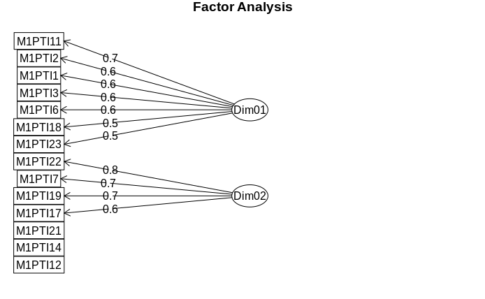

```r
Modele$efa.oblimin$loadings %>% fa.diagram(simple = F, cut = .3)
```

On retrouve nos 3 items à exclure.

Ce modèle retourne également le résultat d’une transformation de Schmid-Leiman sur la rotation oblique précédente.

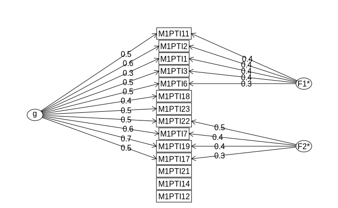

```r
Modele$B.SL %>% omega.diagram(sl = T, cut = .3, gcut = .3)
```

Cela nous donne une assez bonne idée de ce que pourrait être notre analyse confirmatoire. Mais quels en seraient les coefficients?

```r
Modele$meas
```

```
           ECV        omega_a        omega_t        omega_h omega_tot_diff
     0.6695350      0.7801880      0.8547341      0.6668533      0.7444589
```

On retrouve des coefficients légèrement surestimés, mais dans l’ordre de grandeur de l’analyse de la matrice pleine.

# Analyse bifactorielle confirmatoire

On réduit immédiatement le périmètre aux items saturant un tant soit peu le facteur g hypothétique.

```r
Items_high_order =
  cbind.data.frame(item = rownames(Modele$B.SL),
                   Modele$B.SL) %>%
  pivot_longer(cols = -item, names_to = "Factor", values_to = "loadings") %>%
  filter(abs(loadings)>.3) %>%
  pivot_wider(names_from = "Factor", values_from = "loadings") %>%
  drop_na("g") %>% select(-g)
Items_high_order
```

| item | F1* | F2* |
| --- | --- | --- |
| M1PTI1 | 0.3739951 | NA |
| M1PTI2 | 0.3823019 | NA |
| M1PTI3 | 0.3575543 | NA |
| M1PTI6 | 0.3434435 | NA |
| M1PTI7 | NA | 0.4238122 |
| M1PTI11 | 0.4006548 | NA |
| M1PTI17 | NA | 0.3446645 |
| M1PTI18 | NA | NA |
| M1PTI19 | NA | 0.3943386 |
| M1PTI22 | NA | 0.4778413 |

[output cut: 1 more lines]

Et on les attribue à une dimension. Le modèle bifactoriel implique que les facteurs résiduels soient orthogonaux: un item ne peut saturer que le facteur général et une dimension résiduelle.  
A noter qu’un item peut ne saturer que le facteur général.

```r
Dims =
  Items_high_order %>%
  pivot_longer(
    cols = -item,
    names_to = "Factor",
    values_to = "loadings",
    values_drop_na = T
  ) %>%
  left_join(x = Items_high_order %>% select(item),
            by = "item") %>%
  pull(Factor)
Dims
```

```
 [1] "F1*" "F1*" "F1*" "F1*" "F2*" "F1*" "F2*" NA    "F2*" "F2*" NA
```

Et on applique la même fonction, en indiquant le choix du modèle.

```r
Start = Sys.time()
ModeleBifac =
  DATA %>%
  select(Items_high_order$item %>% as.character()) %>%
  tam.fa(
    irtmodel = "bifactor2",
    dims = Dims,
    control = list(increment.factor = 1.2,
                   progress = FALSE)
  )
Sys.time() - Start
```

```
Time difference of 1.70423 mins
```

et on récupère les statistiques de ce modèle.

```r
ModeleBifac %>% summary()
```

```
------------------------------------------------------------
TAM 3.3-10 (2019-08-23 13:42:07)
R version 3.6.2 (2019-12-12) x86_64, linux-gnu | nodename=Dossantos | login=reinaldo

Date of Analysis: 2020-01-24 17:40:09
Time difference of 1.683311 mins
Computation time: 1.683311

Multidimensional Item Response Model in TAM

IRT Model: bifactor2
Call:
tam.mml.2pl(resp = resp, irtmodel = irtmodel2, pid = pid, variance.fixed = variance.fixed,
    Q = Q, pweights = pweights, control = con)

------------------------------------------------------------
Number of iterations = 53
Quasi Monte Carlo integration with 1500 integration points

Deviance = 68493.15
Log likelihood = -34246.57
Number of persons = 6371
Number of persons used = 6371
Number of items = 11
Number of estimated parameters = 31
    Item threshold parameters = 11
    Item slope parameters = 20
    Regression parameters = 0
    Variance/covariance parameters = 0

AIC = 68555  | penalty = 62    | AIC=-2*LL + 2*p
AIC3 = 68586  | penalty = 93    | AIC3=-2*LL + 3*p
BIC = 68765  | penalty = 271.54    | BIC=-2*LL + log(n)*p
aBIC = 68666  | penalty = 173.02    | aBIC=-2*LL + log((n-2)/24)*p  (adjusted BIC)
CAIC = 68796  | penalty = 302.54    | CAIC=-2*LL + [log(n)+1]*p  (consistent AIC)
AICc = 68555  | penalty = 62.31    | AICc=-2*LL + 2*p + 2*p*(p+1)/(n-p-1)  (bias corrected AIC)

------------------------------------------------------------
EAP Reliability
 Dim1  Dim2  Dim3
0.682 0.142 0.256
------------------------------------------------------------
Covariances and Variances
     [,1] [,2] [,3]
[1,]    1    0    0
[2,]    0    1    0
[3,]    0    0    1
------------------------------------------------------------
Correlations and Standard Deviations (in the diagonal)
     [,1] [,2] [,3]
[1,]    1    0    0
[2,]    0    1    0
[3,]    0    0    1
------------------------------------------------------------
Regression Coefficients
     [,1] [,2] [,3]
[1,]    0    0    0
------------------------------------------------------------
Item Parameters -A*Xsi
```

| item | N | M | xsi.item | AXsi_.Cat1 | B.Cat1.Dim1 | B.Cat1.Dim2 | B.Cat1.Dim3 |
| --- | --- | --- | --- | --- | --- | --- | --- |
| M1PTI1 | 6371 | 0.773 | -1.443 | -1.443 | 0.832 | 0.450 | 0.000 |
| M1PTI2 | 6371 | 0.762 | -1.810 | -1.810 | 1.834 | 0.313 | 0.000 |
| M1PTI3 | 6371 | 0.846 | -2.197 | -2.197 | 1.242 | 0.367 | 0.000 |
| M1PTI6 | 6371 | 0.571 | -0.430 | -0.430 | 1.431 | 0.779 | 0.000 |
| M1PTI7 | 6371 | 0.163 | 2.675 | 2.675 | 1.698 | 0.000 | 1.240 |
| M1PTI11 | 6371 | 0.796 | -1.992 | -1.992 | 1.421 | 0.884 | 0.000 |
| M1PTI17 | 6371 | 0.259 | 1.339 | 1.339 | 0.943 | 0.000 | 0.791 |
| M1PTI18 | 6371 | 0.611 | -0.565 | -0.565 | 1.090 | 0.000 | 0.000 |
| M1PTI19 | 6371 | 0.204 | 2.634 | 2.634 | 2.405 | 0.000 | 1.204 |
| M1PTI22 | 6371 | 0.187 | 2.307 | 2.307 | 1.240 | 0.000 | 1.499 |

[output cut: 1 more lines]

```
------------------------------------------------------------

Standardized Factor Loadings (Bifactor Model)
        Dim01 Dim02 Dim03
M1PTI1  0.427 0.231 0.000
M1PTI2  0.728 0.124 0.000
M1PTI3  0.581 0.172 0.000
M1PTI6  0.608 0.331 0.000
M1PTI7  0.628 0.000 0.459
M1PTI11 0.596 0.371 0.000
M1PTI17 0.449 0.000 0.377
M1PTI18 0.540 0.000 0.000
M1PTI19 0.756 0.000 0.378
M1PTI22 0.480 0.000 0.580
M1PTI23 0.650 0.000 0.000

Dimensionality/Reliability Statistics

ECV = 0.767
Omega Asymptotical = 0.898
Omega Total = 0.886
Omega Hierarchical = 0.796
Omega Total (GY) = 0.786
  Omega Total GY (Green & Yang, 2009) includes item difficulties
  and estimates the reliability of the sum score.
```

Encore une fois, des paramètres légèrement surestimés. Mais l’hypothèse d’unidimensionnalité semble tenir.

# Analyse unidimensionnelle

On va donc poursuivre avec une étude unidimensionnelle, sur le périmètre restreint.

```r
Start = Sys.time()
Modele_Uni =
  DATA %>%
  select(Items_high_order$item %>% as.character()) %>%
  tam.mml.2pl(irtmodel = "2PL",
              control = list(increment.factor = 1.2,
                             progress = FALSE))
Sys.time() - Start
```

```
Time difference of 0.9988711 secs
```

et on compare les 3 modèles!

```r
IRT.compareModels(ModeleBifac, Modele_Uni, Modele)
```

```
$IC
        Model   loglike Deviance Npars Nobs      AIC      BIC     AIC3
1 ModeleBifac -34246.57 68493.15    31 6371 68555.15 68764.69 68586.15
2  Modele_Uni -34384.20 68768.40    22 6371 68812.40 68961.11 68834.40
3      Modele -45912.11 91824.23    41 6371 91906.23 92183.37 91947.23
      AICc     CAIC
1 68555.46 68795.69
2 68812.56 68983.11
3 91906.77 92224.37

$LRtest
       Model1      Model2        Chi2 df p
1  Modele_Uni ModeleBifac    275.2531  9 0
2 ModeleBifac      Modele -23331.0825 10 1
3  Modele_Uni      Modele -23055.8293 19 1

attr(,"class")
[1] "IRT.compareModels"
```

# Vérification de l’hypothèse d’unidimensionnalité

## Par les paramètres d’item

Une façon de vérifier tout cela est de comparer les paramètres d’item pour les deux modèles. Si l’hypothèse d’unidimensionnalité tient, il doit y avoir peu d’écart entre les paramètres d’item sous les deux modèles.  
Il s’agit ici de comparer le facteur général du modèle bifactoriel avec le modèle unidimensionnel.

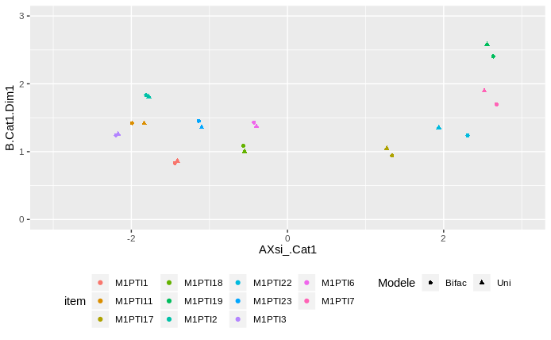

```r
list(Bifac = ModeleBifac,
     Uni = Modele_Uni) %>%
  map(.f = ~ .$item) %>%
  bind_rows(.id = "Modele") %>%
  ggplot(mapping = aes(x = AXsi_.Cat1, y = B.Cat1.Dim1)) +
  geom_point(mapping = aes(shape = Modele, colour = item)) +
  theme(legend.position = "bottom") +
  xlim(-3, 3) + ylim(0, 3)
```

L’écart s’explique par le fait que dans le modèle unidimensionnel, la variance résiduelle est incluse dans la dimension, et pas dans le modèle bifactoriel.

## Par l’estimateur des scores

Le modèle bifactoriel n’est pas compatible avec le WLE. Néanmoins, on peut s’appuyer sur l’EAP pour comparer les scores sous les deux modèles.

```r
KOR =
  list(Bifac = ModeleBifac,
     Uni = Modele_Uni) %>%
  map(.f = ~.$person) %>%
  reduce(.f = full_join, by = "pid")%>%
  select(pid, starts_with("EAP")) %>%
  select(-pid) %>% cor()
```

On retrouve:

- le score unidimensionnel: **EAP**
- le score du facteur général: **EAP.Dim1**
- le score des deux facteurs résiduels: **EAP.Dim2** et **EAP.Dim3**

Quelle est la corrélation (avec significativité) entre ces différents scores?

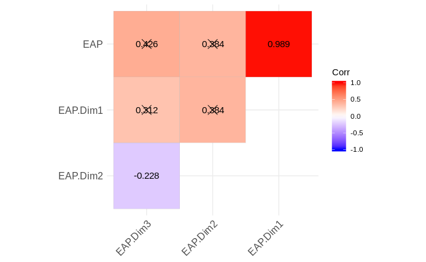

```r
KOR %>%
  ggcorrplot::ggcorrplot(
    type = "upper",
    hc.order = T,
    lab = T,
    digits = 3,
    p.mat = ggcorrplot::cor_pmat(KOR),
    sig.level = 0.05
  )
```

On en conclut que:

- les scores du facteur général et du modèle unidimensionnel sont monstrueusement corrélés. Cela valide l’hypothèse d’unidimensionnalité
- les deux facteurs résiduels sont très légèrement corrélés négativement. Ce n’est pas incohérent, puisqu’ils représentent ce qui n’est pas commun aux deux dimensions de l’EFA.
- il n’y a pas de corrélation significative entre ces deux facteurs et la dimension principale. Là aussi, c’est très cohérent, puisque ces deux facteurs sont ce qui n’est **pas** dans le facteur général.